# Prosper loans project

### by Michał Kaszuba

This project was created during Data Analyst Nanodegree by Udacity [Visit Udacity](https://www.udacity.com) Data set was downloaded form Udacity site

This data set contains 113,937 loans with 81 variables on each loan, including loan amount, borrower rate (or interest rate), current loan status, borrower income, and many others.

I will try to anwser following questions:

Are people who own property are more willing to take loans?

Is specific occupations are more willing to take loans, and which one has the highest debts (Income to debt ratio)?

What affects the borrower’s APR or interest rate?

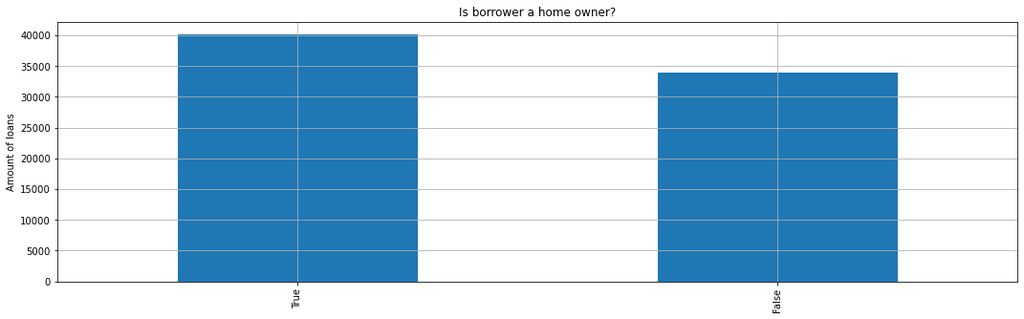

Yes. Most of borrowers got a property. Diffrence is not huge less then 10%.

Let's check the most popular occupations among borrowers.

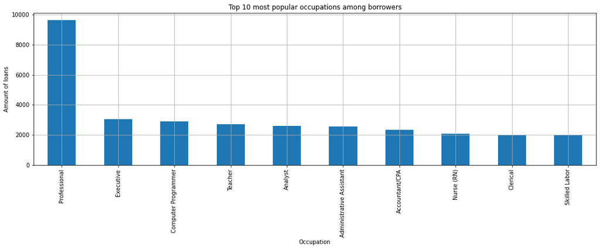

Professionals are by far the most popular occupation among borrower with almost triple of occurs of the second one on list Executive. We got similar levels of loans among places 2 and 10.

What was the average Debt to Income ratio for each occupation?

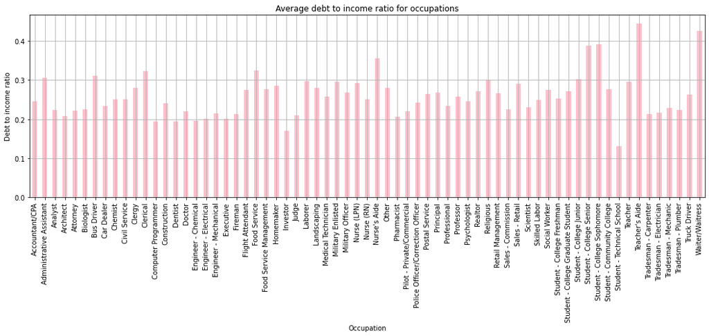

Let's check the average borrowers ARP among diffrent occupations.

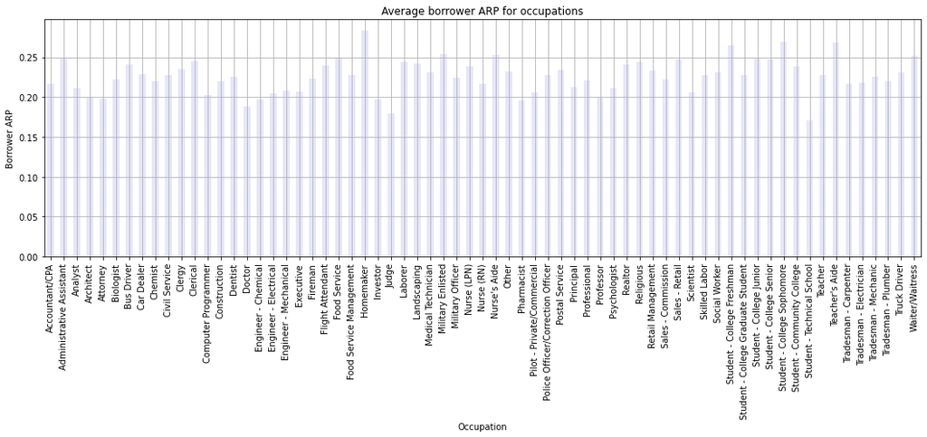

Most borrowers have ARP between 20% and 25%. Homemakers have the highest average ARP among occupations. Teacher's Aides have very high average ARP and Students in Technical schools lowest. We may expect that Income to Debt Ratio has some influence on borrowers ARP since most of the occupations with higher debt to income ratio has higher ARP as well.

Do people with better Prosper Score gets better ARP's?

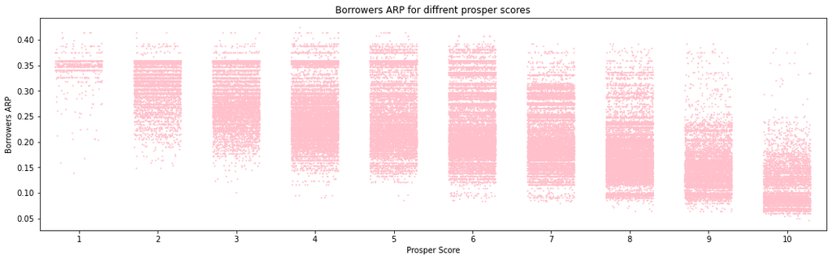

This one is very clear: better Prosper Score We have better ARP We are getting.

Was the Borrower Rate actual ARP?

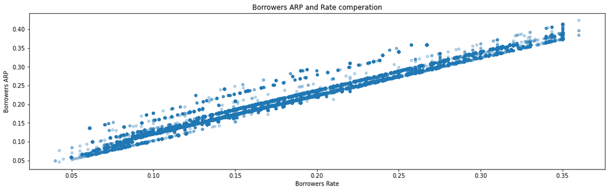

What Was the borrowers ARP for diffrent prosper scores in relation to owning a property?

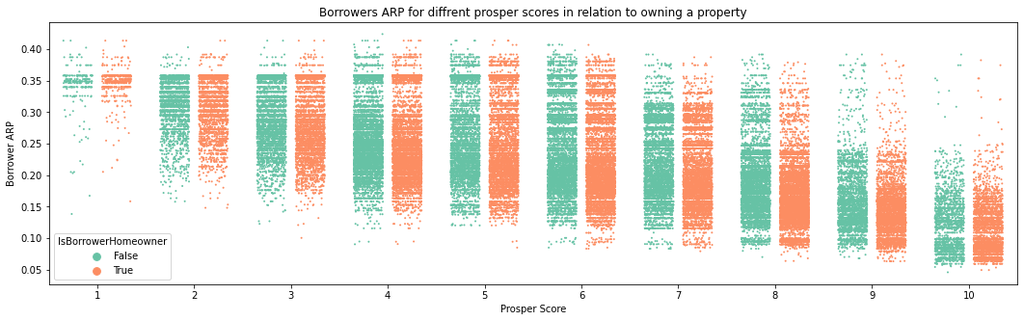

Having a property seems to have no effect on borrowers ARP, no matter what prosper score the borrower has.

# Conclusions